# Kelp Canopy Cover Summary Using Three Region Shapefiles

Gina Contolini

Updated 10 May 2022

For more reports like this, visit my RPubs user profile: https://rpubs.com/gcontolini

# Objective

Summarize California kelp abundance trends from Landsat satellite imagery (SBC LTER et al. 2022) in three regions: north (Oregon to San Frrancisco), cenral (San Francisco to Point Conception), and south (Point Conception to Mexico).

# Methods

## Satellite imagery

Kelp canopy area data are from the Santa Barbara Coastal Long-term Ecological Research Landsat satellite data series updated through all four quarters of 2021 (Santa Barbara Coastal LTER et al. 2022; https://portal.edirepository.org/nis/mapbrowse?scope=knb-lter-sbc&identifier=74&revision=15). The data represents a time series of canopy area of giant kelp, *Macrocystis pyrifera*, and bull kelp, *Nereocystis luetkeana* derived from Landsat 5 Thematic Mapper (TM), Landsat 7 Enhanced Thematic Mapper Plus (ETM+), and Landsat 8 Operational Land Imager (OLI) satellite imagery, along with relevant metadata. The kelp canopy is composed of the portions of fronds and stipes floating on the surface of the water. Canopy area (m) data are given for individual 30 x 30 meter pixels for all coastal areas of California, including the Northern and Southern Channel Islands.

Data were derived from the three Landsat sensors listed above. Observations are made on a 16 day repeat cycle for each instrument, but the temporal coverage is irregular because of cloud cover, instrument failure, and the mission length of each sensor (TM: 1984 – 2011, ETM+: 1999 – present, OLI: 2013 – present). Estimates of canopy area are derived from the fractional cover of kelp canopy determined from satellite surface reflectance. Updates to the 2021 dataset include correcting cloud reflectance errors and improving the landmasking procedure, which increased the detection of kelp especially in the northern region. The different Landsat sensors were calibrated to each other using simulated Landsat data derived from hyperspectral imagery. Missing data due to the ETM+ scan line corrector error were filled using a synchrony-based gap filling method.

Data are organized into a single NetCDF file and contain the quarterly area means for each Landsat pixel across the three sensors. Relevant metadata such as number of Landsat estimates from which the mean was derived, the number of estimates from each sensor, standard error for each quarterly estimate, spatial coordinates, and date are all included in the file.

## Plotting

Figures were created using the above dataset in conjunction with shapefiles of state waters divided into three regions as described above.

# Figures

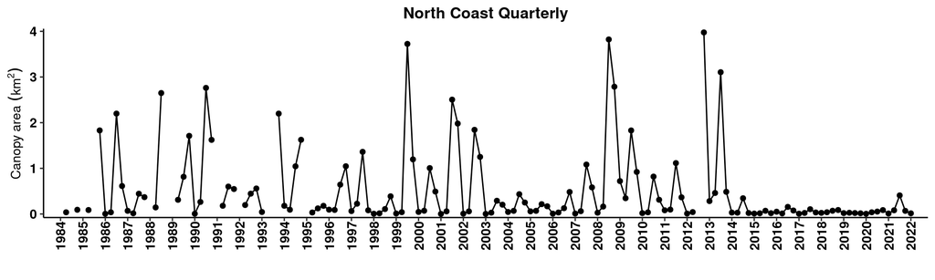

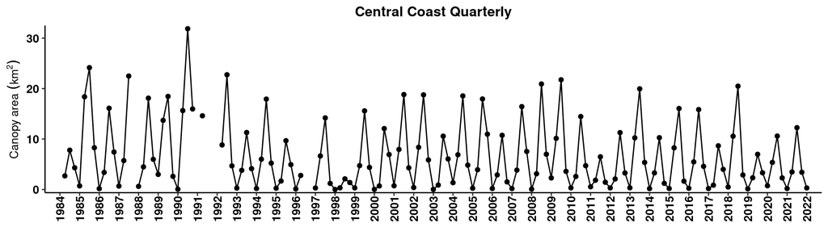

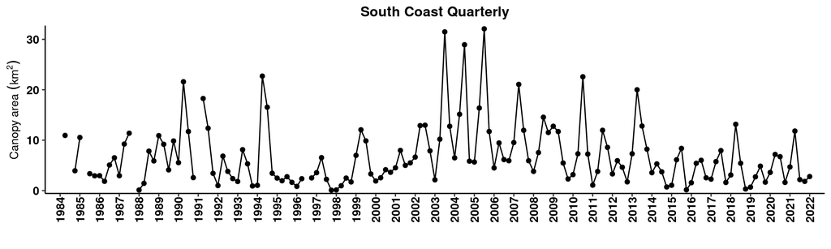

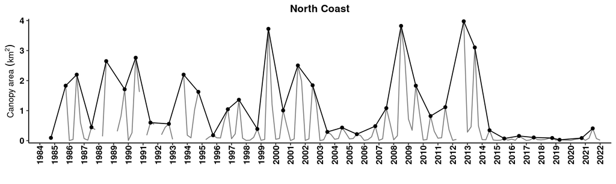

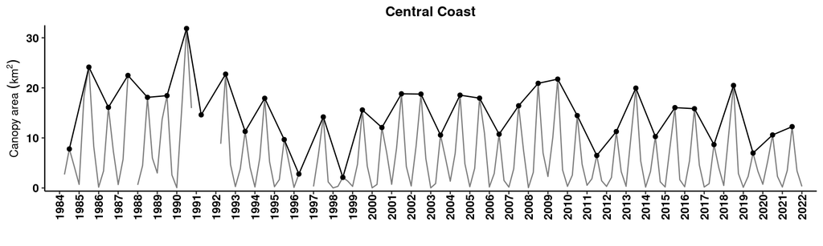

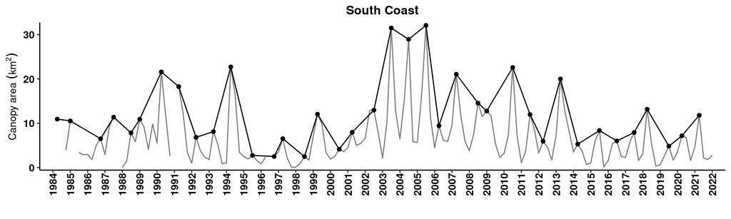

# Tables

Number of quarters with maximum annual canopy area

| region | quarter | number |
| --- | --- | --- |
| Central | 1 | 1 |
| Central | 2 | 2 |
| Central | 3 | 36 |
| Central | 4 | 0 |
| North | 1 | 1 |
| North | 2 | 1 |
| North | 3 | 24 |
| North | 4 | 13 |
| South | 1 | 4 |
| South | 2 | 17 |
| South | 3 | 16 |
| South | 4 | 2 |

# Literature Cited

Santa Barbara Coastal LTER, T. Bell, K. Cavanaugh, and D. Siegel. 2022. SBC LTER: Time series of quarterly NetCDF files of kelp biomass in the canopy from Landsat 5, 7 and 8, since 1984 (ongoing) ver 14. Environmental Data Initiative. https://doi.org/10.6073/pasta/89b63c4b49b80fb839613e9d389d9902 (Accessed 2022-05-02).